# Example clustering analysis

### Original data

Most of the original variables are categorical variables. For a better visualization of the change over time, we use alluvial plots and plot every item (variable) separately.

Define the plotting function for alluvial plots:

```r
plot_alluvial <- function(data = original_data,
                          num_clus = 2,
                          var_name) {
  clus_assign <- paste0("assignment_num_clus_", num_clus)

  p <- data %>%
    ggplot(aes(x = visit,
               stratum = .data[[var_name]],
               alluvium = ID,
               fill = .data[[var_name]],
               label = .data[[var_name]])) +
    scale_fill_brewer(type = "qual", palette = "Set2") +
    geom_flow(stat = "alluvium", lode.guidance = "frontback",
              color = "darkgray") +geom_stratum() +
    facet_wrap(~as.factor(.data[[clus_assign]])) +
    theme_bw() +
    theme(legend.position = "bottom") +
    ylab("number of subjects") +
    ggtitle(paste0("Distribution of ", var_name, " across clusters"))

  print(p)
}
```

Questionnaire A:

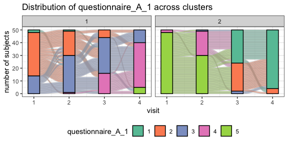

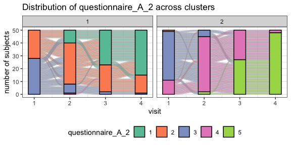

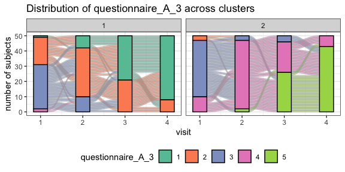

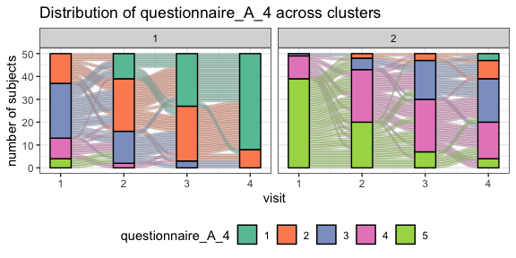

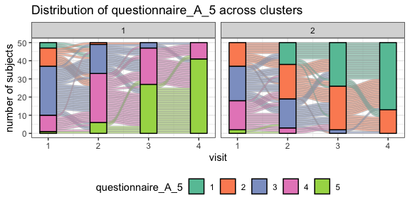

```r
colnames(original_data)[grepl("^questionnaire_A", colnames(original_data))] %>%
  walk(~plot_alluvial(num_clus = 2, var_name = .x))
```

Questionnaire B:

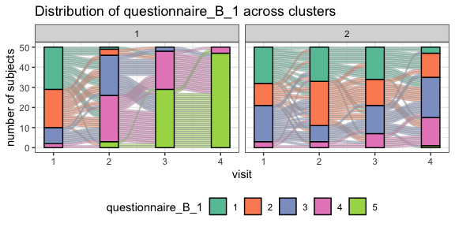

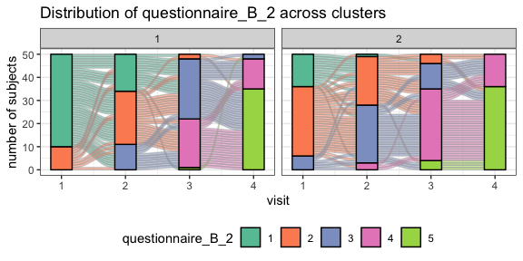

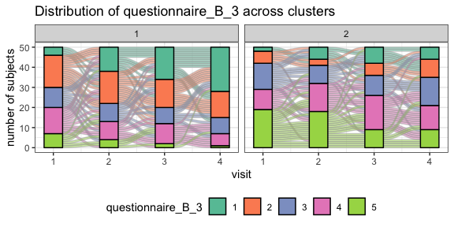

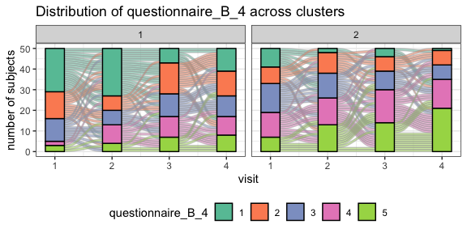

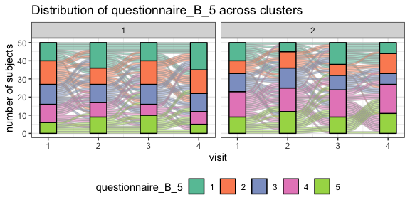

```r
colnames(original_data)[grepl("^questionnaire_B", colnames(original_data))] %>%
  walk(~plot_alluvial(num_clus = 2, var_name = .x))
```

Questionnaire C:

As questionnaire C contains continuous variables, use again a spaghetti plot:

```r
# first define plot function similar to the first spaghetti plot function but
# suited for the original data
plot_spaghetti_2 <- function(data,
                             var_name,
                             num_clus = 2,
                             scale_arg = "fixed") {

  clus_assign <- paste0("assignment_num_clus_", num_clus)
  plot_data <- data %>%
    pivot_longer(
      cols = all_of(var_name),
      names_to = "variable"
    ) %>%
    # this step to create a ID per variable is needed, otherwise
    # ggplot can't differentiate between the different variables
    mutate(ID = paste0(ID, "_", variable),
           across(c(visit, variable, ID), as.factor))

  additional_data <- plot_data %>%
    select(visit, value, variable, .data[[clus_assign]]) %>%
    group_by(visit, variable, .data[[clus_assign]]) %>%
    summarise(mean = mean(value, na.rm = TRUE),
              sd = sd(value, na.rm = TRUE)) %>%
    mutate(ID = 1)

  p <- ggplot(data = plot_data) +
    geom_line(mapping = aes(x = visit, y = value, col = variable, group = ID),
              alpha = 0.4) +
    geom_ribbon(data = additional_data,
                mapping = aes(x = visit, y = mean, ymin = mean - sd, ymax = mean + sd,
                              fill = variable, group = variable), alpha = 0.3) +
    geom_line(data = additional_data,
              mapping = aes(x = visit, y = mean, col = variable, group = variable),
              size = 2) +
    facet_wrap(~as.factor(.data[[clus_assign]]), scales = scale_arg) +
    theme_bw()

  plot(p)
}
```

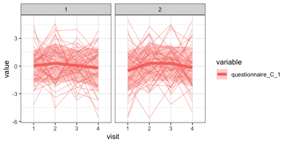

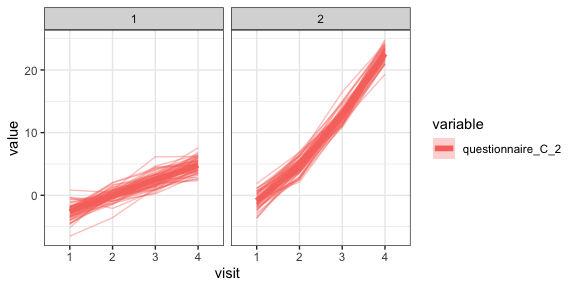

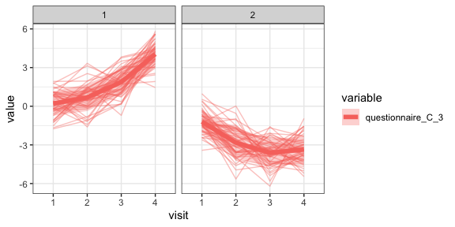

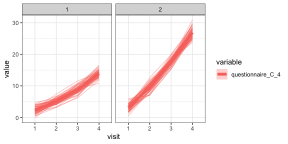

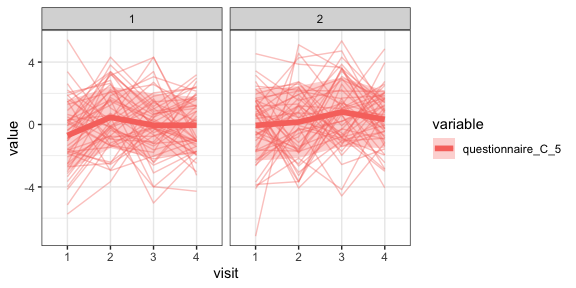

```r
colnames(original_data)[grepl("^questionnaire_C", colnames(original_data))] %>%
  walk(~plot_spaghetti_2(num_clus = 2, data = original_data, var_name = .x))
```

The comparison of the two clusters regarding the original variables show differences how some items of the categorical questionnaires and some variables of the continuous questionnaires differ between the two clusters.

### Cluster comparison

As a final step, variables that were not used in the clustering, for example cross-sectional variables, can be compared across the found clusters. In this case, `single_continuous_variable` only has one value per subject and was left out from the clustering:

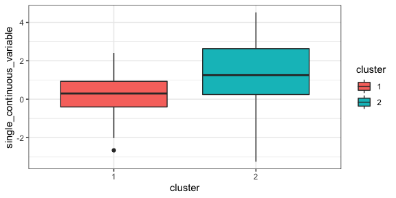

```r
original_data %>%
  filter(visit == 1) %>%
  mutate(cluster = as.factor(assignment_num_clus_2)) %>%
  ggplot(aes(x = cluster, y = single_continuous_variable,
             fill = cluster)) +
  geom_boxplot() +
  theme_bw()
```

Also the left-out variable shows a different behavior between the two clusters.